# Risk Factor Analysis

## Outcome Variable

**Outcome Variable:** ever_stunted

## Predictor Variables

**Intervention Variable:** vagbrth

**Adjustment Set:**

- arm
- W_mage
- meducyrs
- feducyrs
- W_mhtcm
- W_mwtkg
- single
- brthmon
- W_parity
- delta_W_mage
- delta_meducyrs
- delta_feducyrs
- delta_W_mhtcm
- delta_W_mwtkg
- delta_single
- delta_brthmon
- delta_W_parity

## Stratifying Variables

The analysis was stratified on these variable(s):

- agecat
- studyid
- country

## Data Summary

| agecat | studyid | country | vagbrth | ever_stunted | n_cell | n |
| --- | --- | --- | --- | --- | --- | --- |
| 0-24 months (no birth st.) | ki1000108-CMC-V-BCS-2002 | INDIA | 0 | 0 | 3 | 296 |
| 0-24 months (no birth st.) | ki1000108-CMC-V-BCS-2002 | INDIA | 0 | 1 | 17 | 296 |
| 0-24 months (no birth st.) | ki1000108-CMC-V-BCS-2002 | INDIA | 1 | 0 | 25 | 296 |
| 0-24 months (no birth st.) | ki1000108-CMC-V-BCS-2002 | INDIA | 1 | 1 | 251 | 296 |
| 0-24 months (no birth st.) | ki1000108-IRC | INDIA | 0 | 0 | 24 | 360 |
| 0-24 months (no birth st.) | ki1000108-IRC | INDIA | 0 | 1 | 35 | 360 |
| 0-24 months (no birth st.) | ki1000108-IRC | INDIA | 1 | 0 | 123 | 360 |
| 0-24 months (no birth st.) | ki1000108-IRC | INDIA | 1 | 1 | 178 | 360 |
| 0-24 months (no birth st.) | ki1017093b-PROVIDE | BANGLADESH | 0 | 0 | 97 | 634 |
| 0-24 months (no birth st.) | ki1017093b-PROVIDE | BANGLADESH | 0 | 1 | 46 | 634 |
| 0-24 months (no birth st.) | ki1017093b-PROVIDE | BANGLADESH | 1 | 0 | 299 | 634 |
| 0-24 months (no birth st.) | ki1017093b-PROVIDE | BANGLADESH | 1 | 1 | 192 | 634 |
| 0-24 months (no birth st.) | ki1017093c-NIH-Crypto | BANGLADESH | 0 | 0 | 117 | 432 |
| 0-24 months (no birth st.) | ki1017093c-NIH-Crypto | BANGLADESH | 0 | 1 | 58 | 432 |
| 0-24 months (no birth st.) | ki1017093c-NIH-Crypto | BANGLADESH | 1 | 0 | 136 | 432 |
| 0-24 months (no birth st.) | ki1017093c-NIH-Crypto | BANGLADESH | 1 | 1 | 121 | 432 |
| 0-24 months (no birth st.) | ki1066203-TanzaniaChild2 | TANZANIA, UNITED REPUBLIC OF | 0 | 0 | 145 | 2207 |
| 0-24 months (no birth st.) | ki1066203-TanzaniaChild2 | TANZANIA, UNITED REPUBLIC OF | 0 | 1 | 47 | 2207 |
| 0-24 months (no birth st.) | ki1066203-TanzaniaChild2 | TANZANIA, UNITED REPUBLIC OF | 1 | 0 | 1402 | 2207 |
| 0-24 months (no birth st.) | ki1066203-TanzaniaChild2 | TANZANIA, UNITED REPUBLIC OF | 1 | 1 | 613 | 2207 |
| 0-24 months (no birth st.) | ki1119695-PROBIT | BELARUS | 0 | 0 | 1640 | 16742 |
| 0-24 months (no birth st.) | ki1119695-PROBIT | BELARUS | 0 | 1 | 294 | 16742 |
| 0-24 months (no birth st.) | ki1119695-PROBIT | BELARUS | 1 | 0 | 12427 | 16742 |
| 0-24 months (no birth st.) | ki1119695-PROBIT | BELARUS | 1 | 1 | 2381 | 16742 |
| 0-24 months (no birth st.) | ki1126311-ZVITAMBO | ZIMBABWE | 0 | 0 | 731 | 12495 |
| 0-24 months (no birth st.) | ki1126311-ZVITAMBO | ZIMBABWE | 0 | 1 | 356 | 12495 |
| 0-24 months (no birth st.) | ki1126311-ZVITAMBO | ZIMBABWE | 1 | 0 | 7696 | 12495 |
| 0-24 months (no birth st.) | ki1126311-ZVITAMBO | ZIMBABWE | 1 | 1 | 3712 | 12495 |
| 0-24 months (no birth st.) | kiGH5241-JiVitA-3 | BANGLADESH | 0 | 0 | 979 | 18384 |
| 0-24 months (no birth st.) | kiGH5241-JiVitA-3 | BANGLADESH | 0 | 1 | 198 | 18384 |

[output cut: 78 more lines]

The following strata were considered:

- agecat: 0-24 months (no birth st.), studyid: ki1000108-CMC-V-BCS-2002, country: INDIA
- agecat: 0-24 months (no birth st.), studyid: ki1000108-IRC, country: INDIA
- agecat: 0-24 months (no birth st.), studyid: ki1017093b-PROVIDE, country: BANGLADESH
- agecat: 0-24 months (no birth st.), studyid: ki1017093c-NIH-Crypto, country: BANGLADESH
- agecat: 0-24 months (no birth st.), studyid: ki1066203-TanzaniaChild2, country: TANZANIA, UNITED REPUBLIC OF
- agecat: 0-24 months (no birth st.), studyid: ki1119695-PROBIT, country: BELARUS
- agecat: 0-24 months (no birth st.), studyid: ki1126311-ZVITAMBO, country: ZIMBABWE
- agecat: 0-24 months (no birth st.), studyid: kiGH5241-JiVitA-3, country: BANGLADESH
- agecat: 0-24 months (no birth st.), studyid: kiGH5241-JiVitA-4, country: BANGLADESH
- agecat: 0-6 months (no birth st.), studyid: ki1000108-CMC-V-BCS-2002, country: INDIA
- agecat: 0-6 months (no birth st.), studyid: ki1000108-IRC, country: INDIA
- agecat: 0-6 months (no birth st.), studyid: ki1017093b-PROVIDE, country: BANGLADESH
- agecat: 0-6 months (no birth st.), studyid: ki1017093c-NIH-Crypto, country: BANGLADESH
- agecat: 0-6 months (no birth st.), studyid: ki1066203-TanzaniaChild2, country: TANZANIA, UNITED REPUBLIC OF
- agecat: 0-6 months (no birth st.), studyid: ki1119695-PROBIT, country: BELARUS
- agecat: 0-6 months (no birth st.), studyid: ki1126311-ZVITAMBO, country: ZIMBABWE
- agecat: 0-6 months (no birth st.), studyid: kiGH5241-JiVitA-3, country: BANGLADESH
- agecat: 0-6 months (no birth st.), studyid: kiGH5241-JiVitA-4, country: BANGLADESH
- agecat: 6-24 months, studyid: ki1000108-CMC-V-BCS-2002, country: INDIA
- agecat: 6-24 months, studyid: ki1000108-IRC, country: INDIA
- agecat: 6-24 months, studyid: ki1017093b-PROVIDE, country: BANGLADESH
- agecat: 6-24 months, studyid: ki1017093c-NIH-Crypto, country: BANGLADESH
- agecat: 6-24 months, studyid: ki1066203-TanzaniaChild2, country: TANZANIA, UNITED REPUBLIC OF
- agecat: 6-24 months, studyid: ki1119695-PROBIT, country: BELARUS
- agecat: 6-24 months, studyid: ki1126311-ZVITAMBO, country: ZIMBABWE
- agecat: 6-24 months, studyid: kiGH5241-JiVitA-3, country: BANGLADESH
- agecat: 6-24 months, studyid: kiGH5241-JiVitA-4, country: BANGLADESH

### Dropped Strata

Some strata were dropped due to rare outcomes:

- agecat: 0-24 months (no birth st.), studyid: ki1000108-CMC-V-BCS-2002, country: INDIA
- agecat: 6-24 months, studyid: ki1000108-CMC-V-BCS-2002, country: INDIA

## Methods Detail

We’re interested in the causal parameters $E[Y_a]$ for all values of $a \in \mathcal{A}$. These parameters represent the mean outcome if, possibly contrary to fact, we intervened to set all units to have $A=a$. Under the randomization and positivity assumptions, these are identified by the statistical parameters $\psi_a=E_W[E_{Y|A,W}(Y|A=a,W)]$. In addition, we’re interested in the mean of $Y$, $E[Y]$ under no intervention (the observed mean). We will estimate these parameters by using SuperLearner to fit the relevant likelihood factors – $E_{Y|A,W}(Y|A=a,W)$ and $p(A=a|W)$, and then updating our likelihood fit using a joint TMLE.

For unadjusted analyses ($W=\{\}$), initial likelihoods were estimated using Lrnr_glm to estimate the simple $E(Y|A)$ and Lrnr_mean to estimate $p(A)$. For adjusted analyses, a small library containing Lrnr_glmnet, Lrnr_xgboost, and Lrnr_mean was used.

Having estimated these parameters, we will then use the delta method to estimate relative risks and attributable risks relative to a prespecified baseline level of $A$.

# Results Detail

## Results Plots

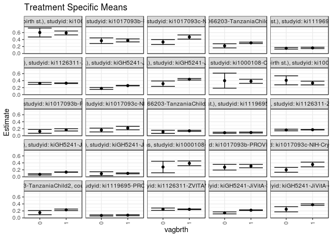

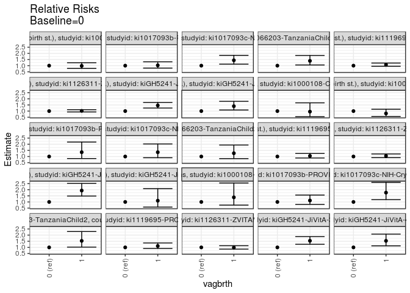

[figure not shown]

[figure not shown]

## Results Table

### Parameter: TSM

| agecat | studyid | country | intervention_level | baseline_level | estimate | ci_lower | ci_upper |
| --- | --- | --- | --- | --- | --- | --- | --- |
| 0-24 months (no birth st.) | ki1000108-IRC | INDIA | 0 | NA | 0.6015471 | 0.4732293 | 0.7298650 |
| 0-24 months (no birth st.) | ki1000108-IRC | INDIA | 1 | NA | 0.5897339 | 0.5340615 | 0.6454062 |
| 0-24 months (no birth st.) | ki1017093b-PROVIDE | BANGLADESH | 0 | NA | 0.3670485 | 0.2862676 | 0.4478295 |
| 0-24 months (no birth st.) | ki1017093b-PROVIDE | BANGLADESH | 1 | NA | 0.3765597 | 0.3338126 | 0.4193068 |
| 0-24 months (no birth st.) | ki1017093c-NIH-Crypto | BANGLADESH | 0 | NA | 0.3287458 | 0.2586335 | 0.3988580 |
| 0-24 months (no birth st.) | ki1017093c-NIH-Crypto | BANGLADESH | 1 | NA | 0.4726544 | 0.4121500 | 0.5331588 |
| 0-24 months (no birth st.) | ki1066203-TanzaniaChild2 | TANZANIA, UNITED REPUBLIC OF | 0 | NA | 0.2203224 | 0.1610354 | 0.2796094 |
| 0-24 months (no birth st.) | ki1066203-TanzaniaChild2 | TANZANIA, UNITED REPUBLIC OF | 1 | NA | 0.3059657 | 0.2858368 | 0.3260946 |
| 0-24 months (no birth st.) | ki1119695-PROBIT | BELARUS | 0 | NA | 0.1500996 | 0.1277446 | 0.1724546 |
| 0-24 months (no birth st.) | ki1119695-PROBIT | BELARUS | 1 | NA | 0.1610792 | 0.1415375 | 0.1806209 |
| 0-24 months (no birth st.) | ki1126311-ZVITAMBO | ZIMBABWE | 0 | NA | 0.3216717 | 0.2936492 | 0.3496943 |
| 0-24 months (no birth st.) | ki1126311-ZVITAMBO | ZIMBABWE | 1 | NA | 0.3270701 | 0.3184788 | 0.3356613 |
| 0-24 months (no birth st.) | kiGH5241-JiVitA-3 | BANGLADESH | 0 | NA | 0.1769307 | 0.1497121 | 0.2041494 |
| 0-24 months (no birth st.) | kiGH5241-JiVitA-3 | BANGLADESH | 1 | NA | 0.2580828 | 0.2500814 | 0.2660841 |
| 0-24 months (no birth st.) | kiGH5241-JiVitA-4 | BANGLADESH | 0 | NA | 0.3133986 | 0.2363960 | 0.3904013 |
| 0-24 months (no birth st.) | kiGH5241-JiVitA-4 | BANGLADESH | 1 | NA | 0.4382890 | 0.4168453 | 0.4597327 |
| 0-6 months (no birth st.) | ki1000108-CMC-V-BCS-2002 | INDIA | 0 | NA | 0.4000000 | 0.1849281 | 0.6150719 |
| 0-6 months (no birth st.) | ki1000108-CMC-V-BCS-2002 | INDIA | 1 | NA | 0.3823529 | 0.3245019 | 0.4402040 |
| 0-6 months (no birth st.) | ki1000108-IRC | INDIA | 0 | NA | 0.4097132 | 0.2806524 | 0.5387740 |
| 0-6 months (no birth st.) | ki1000108-IRC | INDIA | 1 | NA | 0.3312309 | 0.2779904 | 0.3844714 |
| 0-6 months (no birth st.) | ki1017093b-PROVIDE | BANGLADESH | 0 | NA | 0.1246151 | 0.0702100 | 0.1790202 |
| 0-6 months (no birth st.) | ki1017093b-PROVIDE | BANGLADESH | 1 | NA | 0.1683600 | 0.1351117 | 0.2016083 |
| 0-6 months (no birth st.) | ki1017093c-NIH-Crypto | BANGLADESH | 0 | NA | 0.1628640 | 0.1081057 | 0.2176224 |
| 0-6 months (no birth st.) | ki1017093c-NIH-Crypto | BANGLADESH | 1 | NA | 0.2199006 | 0.1698385 | 0.2699628 |
| 0-6 months (no birth st.) | ki1066203-TanzaniaChild2 | TANZANIA, UNITED REPUBLIC OF | 0 | NA | 0.1113157 | 0.0655471 | 0.1570843 |
| 0-6 months (no birth st.) | ki1066203-TanzaniaChild2 | TANZANIA, UNITED REPUBLIC OF | 1 | NA | 0.1410232 | 0.1258354 | 0.1562109 |
| 0-6 months (no birth st.) | ki1119695-PROBIT | BELARUS | 0 | NA | 0.0869972 | 0.0712713 | 0.1027231 |
| 0-6 months (no birth st.) | ki1119695-PROBIT | BELARUS | 1 | NA | 0.0913038 | 0.0775758 | 0.1050318 |
| 0-6 months (no birth st.) | ki1126311-ZVITAMBO | ZIMBABWE | 0 | NA | 0.1644702 | 0.1418317 | 0.1871088 |
| 0-6 months (no birth st.) | ki1126311-ZVITAMBO | ZIMBABWE | 1 | NA | 0.1721903 | 0.1652654 | 0.1791152 |
| 0-6 months (no birth st.) | kiGH5241-JiVitA-3 | BANGLADESH | 0 | NA | 0.0701018 | 0.0517339 | 0.0884696 |
| 0-6 months (no birth st.) | kiGH5241-JiVitA-3 | BANGLADESH | 1 | NA | 0.1351734 | 0.1292816 | 0.1410651 |
| 0-6 months (no birth st.) | kiGH5241-JiVitA-4 | BANGLADESH | 0 | NA | 0.0893737 | 0.0335095 | 0.1452379 |
| 0-6 months (no birth st.) | kiGH5241-JiVitA-4 | BANGLADESH | 1 | NA | 0.0985726 | 0.0856003 | 0.1115449 |
| 6-24 months | ki1000108-IRC | INDIA | 0 | NA | 0.2805454 | 0.1153147 | 0.4457761 |
| 6-24 months | ki1000108-IRC | INDIA | 1 | NA | 0.3860301 | 0.3183958 | 0.4536643 |
| 6-24 months | ki1017093b-PROVIDE | BANGLADESH | 0 | NA | 0.2752010 | 0.1933816 | 0.3570203 |
| 6-24 months | ki1017093b-PROVIDE | BANGLADESH | 1 | NA | 0.3079126 | 0.2593085 | 0.3565167 |
| 6-24 months | ki1017093c-NIH-Crypto | BANGLADESH | 0 | NA | 0.2006519 | 0.1319729 | 0.2693310 |
| 6-24 months | ki1017093c-NIH-Crypto | BANGLADESH | 1 | NA | 0.3529153 | 0.2853471 | 0.4204835 |
| 6-24 months | ki1066203-TanzaniaChild2 | TANZANIA, UNITED REPUBLIC OF | 0 | NA | 0.1512972 | 0.0917333 | 0.2108612 |
| 6-24 months | ki1066203-TanzaniaChild2 | TANZANIA, UNITED REPUBLIC OF | 1 | NA | 0.2317127 | 0.2099034 | 0.2535221 |
| 6-24 months | ki1119695-PROBIT | BELARUS | 0 | NA | 0.0703182 | 0.0548725 | 0.0857639 |
| 6-24 months | ki1119695-PROBIT | BELARUS | 1 | NA | 0.0782128 | 0.0635814 | 0.0928443 |
| 6-24 months | ki1126311-ZVITAMBO | ZIMBABWE | 0 | NA | 0.2489681 | 0.2154645 | 0.2824718 |
| 6-24 months | ki1126311-ZVITAMBO | ZIMBABWE | 1 | NA | 0.2461898 | 0.2362286 | 0.2561511 |
| 6-24 months | kiGH5241-JiVitA-3 | BANGLADESH | 0 | NA | 0.1441475 | 0.1155935 | 0.1727015 |
| 6-24 months | kiGH5241-JiVitA-3 | BANGLADESH | 1 | NA | 0.2214366 | 0.2117464 | 0.2311268 |
| 6-24 months | kiGH5241-JiVitA-4 | BANGLADESH | 0 | NA | 0.2476133 | 0.1730438 | 0.3221827 |
| 6-24 months | kiGH5241-JiVitA-4 | BANGLADESH | 1 | NA | 0.3792600 | 0.3572343 | 0.4012858 |

### Parameter: E(Y)

| agecat | studyid | country | intervention_level | baseline_level | estimate | ci_lower | ci_upper |
| --- | --- | --- | --- | --- | --- | --- | --- |
| 0-24 months (no birth st.) | ki1000108-IRC | INDIA | NA | NA | 0.5916667 | 0.5408218 | 0.6425115 |
| 0-24 months (no birth st.) | ki1017093b-PROVIDE | BANGLADESH | NA | NA | 0.3753943 | 0.3376725 | 0.4131162 |
| 0-24 months (no birth st.) | ki1017093c-NIH-Crypto | BANGLADESH | NA | NA | 0.4143519 | 0.3678455 | 0.4608582 |
| 0-24 months (no birth st.) | ki1066203-TanzaniaChild2 | TANZANIA, UNITED REPUBLIC OF | NA | NA | 0.2990485 | 0.2799429 | 0.3181541 |
| 0-24 months (no birth st.) | ki1119695-PROBIT | BELARUS | NA | NA | 0.1597778 | 0.1408215 | 0.1787342 |
| 0-24 months (no birth st.) | ki1126311-ZVITAMBO | ZIMBABWE | NA | NA | 0.3255702 | 0.3173537 | 0.3337868 |
| 0-24 months (no birth st.) | kiGH5241-JiVitA-3 | BANGLADESH | NA | NA | 0.2535357 | 0.2457345 | 0.2613369 |
| 0-24 months (no birth st.) | kiGH5241-JiVitA-4 | BANGLADESH | NA | NA | 0.4270574 | 0.4065290 | 0.4475857 |
| 0-6 months (no birth st.) | ki1000108-CMC-V-BCS-2002 | INDIA | NA | NA | 0.3835616 | 0.3276935 | 0.4394298 |
| 0-6 months (no birth st.) | ki1000108-IRC | INDIA | NA | NA | 0.3444444 | 0.2952897 | 0.3935992 |
| 0-6 months (no birth st.) | ki1017093b-PROVIDE | BANGLADESH | NA | NA | 0.1593060 | 0.1307970 | 0.1878149 |
| 0-6 months (no birth st.) | ki1017093c-NIH-Crypto | BANGLADESH | NA | NA | 0.1944444 | 0.1570803 | 0.2318086 |
| 0-6 months (no birth st.) | ki1066203-TanzaniaChild2 | TANZANIA, UNITED REPUBLIC OF | NA | NA | 0.1381966 | 0.1237955 | 0.1525978 |
| 0-6 months (no birth st.) | ki1119695-PROBIT | BELARUS | NA | NA | 0.0912784 | 0.0781588 | 0.1043979 |
| 0-6 months (no birth st.) | ki1126311-ZVITAMBO | ZIMBABWE | NA | NA | 0.1709936 | 0.1643878 | 0.1775994 |
| 0-6 months (no birth st.) | kiGH5241-JiVitA-3 | BANGLADESH | NA | NA | 0.1309789 | 0.1253283 | 0.1366296 |
| 0-6 months (no birth st.) | kiGH5241-JiVitA-4 | BANGLADESH | NA | NA | 0.0978125 | 0.0850264 | 0.1105986 |
| 6-24 months | ki1000108-IRC | INDIA | NA | NA | 0.3771186 | 0.3151523 | 0.4390850 |
| 6-24 months | ki1017093b-PROVIDE | BANGLADESH | NA | NA | 0.2997812 | 0.2577294 | 0.3418330 |
| 6-24 months | ki1017093c-NIH-Crypto | BANGLADESH | NA | NA | 0.2923077 | 0.2427834 | 0.3418319 |
| 6-24 months | ki1066203-TanzaniaChild2 | TANZANIA, UNITED REPUBLIC OF | NA | NA | 0.2243995 | 0.2038353 | 0.2449637 |
| 6-24 months | ki1119695-PROBIT | BELARUS | NA | NA | 0.0768510 | 0.0628857 | 0.0908164 |
| 6-24 months | ki1126311-ZVITAMBO | ZIMBABWE | NA | NA | 0.2458186 | 0.2363185 | 0.2553186 |
| 6-24 months | kiGH5241-JiVitA-3 | BANGLADESH | NA | NA | 0.2168053 | 0.2074791 | 0.2261314 |
| 6-24 months | kiGH5241-JiVitA-4 | BANGLADESH | NA | NA | 0.3674386 | 0.3465522 | 0.3883251 |

### Parameter: RR

| agecat | studyid | country | intervention_level | baseline_level | estimate | ci_lower | ci_upper |
| --- | --- | --- | --- | --- | --- | --- | --- |
| 0-24 months (no birth st.) | ki1000108-IRC | INDIA | 0 | 0 | 1.0000000 | 1.0000000 | 1.000000 |
| 0-24 months (no birth st.) | ki1000108-IRC | INDIA | 1 | 0 | 0.9803619 | 0.7764447 | 1.237834 |
| 0-24 months (no birth st.) | ki1017093b-PROVIDE | BANGLADESH | 0 | 0 | 1.0000000 | 1.0000000 | 1.000000 |
| 0-24 months (no birth st.) | ki1017093b-PROVIDE | BANGLADESH | 1 | 0 | 1.0259125 | 0.8027011 | 1.311194 |
| 0-24 months (no birth st.) | ki1017093c-NIH-Crypto | BANGLADESH | 0 | 0 | 1.0000000 | 1.0000000 | 1.000000 |
| 0-24 months (no birth st.) | ki1017093c-NIH-Crypto | BANGLADESH | 1 | 0 | 1.4377506 | 1.1238276 | 1.839363 |
| 0-24 months (no birth st.) | ki1066203-TanzaniaChild2 | TANZANIA, UNITED REPUBLIC OF | 0 | 0 | 1.0000000 | 1.0000000 | 1.000000 |
| 0-24 months (no birth st.) | ki1066203-TanzaniaChild2 | TANZANIA, UNITED REPUBLIC OF | 1 | 0 | 1.3887183 | 1.0537689 | 1.830134 |
| 0-24 months (no birth st.) | ki1119695-PROBIT | BELARUS | 0 | 0 | 1.0000000 | 1.0000000 | 1.000000 |
| 0-24 months (no birth st.) | ki1119695-PROBIT | BELARUS | 1 | 0 | 1.0731488 | 0.9513088 | 1.210594 |
| 0-24 months (no birth st.) | ki1126311-ZVITAMBO | ZIMBABWE | 0 | 0 | 1.0000000 | 1.0000000 | 1.000000 |
| 0-24 months (no birth st.) | ki1126311-ZVITAMBO | ZIMBABWE | 1 | 0 | 1.0167820 | 0.9287455 | 1.113164 |
| 0-24 months (no birth st.) | kiGH5241-JiVitA-3 | BANGLADESH | 0 | 0 | 1.0000000 | 1.0000000 | 1.000000 |
| 0-24 months (no birth st.) | kiGH5241-JiVitA-3 | BANGLADESH | 1 | 0 | 1.4586656 | 1.2490080 | 1.703516 |
| 0-24 months (no birth st.) | kiGH5241-JiVitA-4 | BANGLADESH | 0 | 0 | 1.0000000 | 1.0000000 | 1.000000 |
| 0-24 months (no birth st.) | kiGH5241-JiVitA-4 | BANGLADESH | 1 | 0 | 1.3985032 | 1.0890356 | 1.795911 |
| 0-6 months (no birth st.) | ki1000108-CMC-V-BCS-2002 | INDIA | 0 | 0 | 1.0000000 | 1.0000000 | 1.000000 |
| 0-6 months (no birth st.) | ki1000108-CMC-V-BCS-2002 | INDIA | 1 | 0 | 0.9558824 | 0.5467942 | 1.671033 |
| 0-6 months (no birth st.) | ki1000108-IRC | INDIA | 0 | 0 | 1.0000000 | 1.0000000 | 1.000000 |
| 0-6 months (no birth st.) | ki1000108-IRC | INDIA | 1 | 0 | 0.8084457 | 0.5674587 | 1.151774 |
| 0-6 months (no birth st.) | ki1017093b-PROVIDE | BANGLADESH | 0 | 0 | 1.0000000 | 1.0000000 | 1.000000 |
| 0-6 months (no birth st.) | ki1017093b-PROVIDE | BANGLADESH | 1 | 0 | 1.3510400 | 0.8372280 | 2.180182 |
| 0-6 months (no birth st.) | ki1017093c-NIH-Crypto | BANGLADESH | 0 | 0 | 1.0000000 | 1.0000000 | 1.000000 |
| 0-6 months (no birth st.) | ki1017093c-NIH-Crypto | BANGLADESH | 1 | 0 | 1.3502098 | 0.9015408 | 2.022168 |
| 0-6 months (no birth st.) | ki1066203-TanzaniaChild2 | TANZANIA, UNITED REPUBLIC OF | 0 | 0 | 1.0000000 | 1.0000000 | 1.000000 |
| 0-6 months (no birth st.) | ki1066203-TanzaniaChild2 | TANZANIA, UNITED REPUBLIC OF | 1 | 0 | 1.2668757 | 0.8289807 | 1.936081 |
| 0-6 months (no birth st.) | ki1119695-PROBIT | BELARUS | 0 | 0 | 1.0000000 | 1.0000000 | 1.000000 |
| 0-6 months (no birth st.) | ki1119695-PROBIT | BELARUS | 1 | 0 | 1.0495024 | 0.8802237 | 1.251336 |
| 0-6 months (no birth st.) | ki1126311-ZVITAMBO | ZIMBABWE | 0 | 0 | 1.0000000 | 1.0000000 | 1.000000 |
| 0-6 months (no birth st.) | ki1126311-ZVITAMBO | ZIMBABWE | 1 | 0 | 1.0469393 | 0.9073573 | 1.207994 |
| 0-6 months (no birth st.) | kiGH5241-JiVitA-3 | BANGLADESH | 0 | 0 | 1.0000000 | 1.0000000 | 1.000000 |
| 0-6 months (no birth st.) | kiGH5241-JiVitA-3 | BANGLADESH | 1 | 0 | 1.9282453 | 1.4808588 | 2.510793 |
| 0-6 months (no birth st.) | kiGH5241-JiVitA-4 | BANGLADESH | 0 | 0 | 1.0000000 | 1.0000000 | 1.000000 |
| 0-6 months (no birth st.) | kiGH5241-JiVitA-4 | BANGLADESH | 1 | 0 | 1.1029265 | 0.5831430 | 2.086018 |
| 6-24 months | ki1000108-IRC | INDIA | 0 | 0 | 1.0000000 | 1.0000000 | 1.000000 |
| 6-24 months | ki1000108-IRC | INDIA | 1 | 0 | 1.3759987 | 0.7444333 | 2.543374 |
| 6-24 months | ki1017093b-PROVIDE | BANGLADESH | 0 | 0 | 1.0000000 | 1.0000000 | 1.000000 |
| 6-24 months | ki1017093b-PROVIDE | BANGLADESH | 1 | 0 | 1.1188646 | 0.8013150 | 1.562255 |
| 6-24 months | ki1017093c-NIH-Crypto | BANGLADESH | 0 | 0 | 1.0000000 | 1.0000000 | 1.000000 |
| 6-24 months | ki1017093c-NIH-Crypto | BANGLADESH | 1 | 0 | 1.7588433 | 1.1901204 | 2.599342 |
| 6-24 months | ki1066203-TanzaniaChild2 | TANZANIA, UNITED REPUBLIC OF | 0 | 0 | 1.0000000 | 1.0000000 | 1.000000 |
| 6-24 months | ki1066203-TanzaniaChild2 | TANZANIA, UNITED REPUBLIC OF | 1 | 0 | 1.5315066 | 1.0221614 | 2.294659 |
| 6-24 months | ki1119695-PROBIT | BELARUS | 0 | 0 | 1.0000000 | 1.0000000 | 1.000000 |
| 6-24 months | ki1119695-PROBIT | BELARUS | 1 | 0 | 1.1122706 | 0.9099600 | 1.359561 |
| 6-24 months | ki1126311-ZVITAMBO | ZIMBABWE | 0 | 0 | 1.0000000 | 1.0000000 | 1.000000 |
| 6-24 months | ki1126311-ZVITAMBO | ZIMBABWE | 1 | 0 | 0.9888409 | 0.8593620 | 1.137828 |
| 6-24 months | kiGH5241-JiVitA-3 | BANGLADESH | 0 | 0 | 1.0000000 | 1.0000000 | 1.000000 |
| 6-24 months | kiGH5241-JiVitA-3 | BANGLADESH | 1 | 0 | 1.5361801 | 1.2549895 | 1.880374 |
| 6-24 months | kiGH5241-JiVitA-4 | BANGLADESH | 0 | 0 | 1.0000000 | 1.0000000 | 1.000000 |
| 6-24 months | kiGH5241-JiVitA-4 | BANGLADESH | 1 | 0 | 1.5316628 | 1.1270531 | 2.081526 |

### Parameter: PAR

| agecat | studyid | country | intervention_level | baseline_level | estimate | ci_lower | ci_upper |
| --- | --- | --- | --- | --- | --- | --- | --- |
| 0-24 months (no birth st.) | ki1000108-IRC | INDIA | 0 | NA | -0.0098805 | -0.1274966 | 0.1077357 |
| 0-24 months (no birth st.) | ki1017093b-PROVIDE | BANGLADESH | 0 | NA | 0.0083458 | -0.0635414 | 0.0802330 |
| 0-24 months (no birth st.) | ki1017093c-NIH-Crypto | BANGLADESH | 0 | NA | 0.0856061 | 0.0304514 | 0.1407608 |
| 0-24 months (no birth st.) | ki1066203-TanzaniaChild2 | TANZANIA, UNITED REPUBLIC OF | 0 | NA | 0.0787261 | 0.0215218 | 0.1359304 |
| 0-24 months (no birth st.) | ki1119695-PROBIT | BELARUS | 0 | NA | 0.0096782 | -0.0068029 | 0.0261593 |
| 0-24 months (no birth st.) | ki1126311-ZVITAMBO | ZIMBABWE | 0 | NA | 0.0038985 | -0.0229060 | 0.0307029 |
| 0-24 months (no birth st.) | kiGH5241-JiVitA-3 | BANGLADESH | 0 | NA | 0.0766049 | 0.0499113 | 0.1032985 |
| 0-24 months (no birth st.) | kiGH5241-JiVitA-4 | BANGLADESH | 0 | NA | 0.1136587 | 0.0403399 | 0.1869775 |
| 0-6 months (no birth st.) | ki1000108-CMC-V-BCS-2002 | INDIA | 0 | NA | -0.0164384 | -0.2239010 | 0.1910243 |
| 0-6 months (no birth st.) | ki1000108-IRC | INDIA | 0 | NA | -0.0652688 | -0.1829894 | 0.0524519 |
| 0-6 months (no birth st.) | ki1017093b-PROVIDE | BANGLADESH | 0 | NA | 0.0346909 | -0.0148897 | 0.0842715 |
| 0-6 months (no birth st.) | ki1017093c-NIH-Crypto | BANGLADESH | 0 | NA | 0.0315804 | -0.0123531 | 0.0755139 |
| 0-6 months (no birth st.) | ki1066203-TanzaniaChild2 | TANZANIA, UNITED REPUBLIC OF | 0 | NA | 0.0268809 | -0.0171812 | 0.0709431 |
| 0-6 months (no birth st.) | ki1119695-PROBIT | BELARUS | 0 | NA | 0.0042812 | -0.0094084 | 0.0179707 |
| 0-6 months (no birth st.) | ki1126311-ZVITAMBO | ZIMBABWE | 0 | NA | 0.0065234 | -0.0151700 | 0.0282168 |
| 0-6 months (no birth st.) | kiGH5241-JiVitA-3 | BANGLADESH | 0 | NA | 0.0608772 | 0.0427042 | 0.0790502 |
| 0-6 months (no birth st.) | kiGH5241-JiVitA-4 | BANGLADESH | 0 | NA | 0.0084388 | -0.0438654 | 0.0607430 |
| 6-24 months | ki1000108-IRC | INDIA | 0 | NA | 0.0965733 | -0.0571800 | 0.2503266 |
| 6-24 months | ki1017093b-PROVIDE | BANGLADESH | 0 | NA | 0.0245802 | -0.0472581 | 0.0964185 |
| 6-24 months | ki1017093c-NIH-Crypto | BANGLADESH | 0 | NA | 0.0916558 | 0.0352015 | 0.1481101 |
| 6-24 months | ki1066203-TanzaniaChild2 | TANZANIA, UNITED REPUBLIC OF | 0 | NA | 0.0731023 | 0.0155262 | 0.1306783 |
| 6-24 months | ki1119695-PROBIT | BELARUS | 0 | NA | 0.0065329 | -0.0066295 | 0.0196953 |
| 6-24 months | ki1126311-ZVITAMBO | ZIMBABWE | 0 | NA | -0.0031496 | -0.0352341 | 0.0289349 |
| 6-24 months | kiGH5241-JiVitA-3 | BANGLADESH | 0 | NA | 0.0726577 | 0.0442743 | 0.1010411 |
| 6-24 months | kiGH5241-JiVitA-4 | BANGLADESH | 0 | NA | 0.1198254 | 0.0482183 | 0.1914324 |

### Parameter: PAF

| agecat | studyid | country | intervention_level | baseline_level | estimate | ci_lower | ci_upper |
| --- | --- | --- | --- | --- | --- | --- | --- |
| 0-24 months (no birth st.) | ki1000108-IRC | INDIA | 0 | NA | -0.0166994 | -0.2362515 | 0.1638614 |
| 0-24 months (no birth st.) | ki1017093b-PROVIDE | BANGLADESH | 0 | NA | 0.0222321 | -0.1892882 | 0.1961325 |
| 0-24 months (no birth st.) | ki1017093c-NIH-Crypto | BANGLADESH | 0 | NA | 0.2066024 | 0.0608326 | 0.3297470 |
| 0-24 months (no birth st.) | ki1066203-TanzaniaChild2 | TANZANIA, UNITED REPUBLIC OF | 0 | NA | 0.2632553 | 0.0451010 | 0.4315706 |
| 0-24 months (no birth st.) | ki1119695-PROBIT | BELARUS | 0 | NA | 0.0605730 | -0.0470403 | 0.1571259 |
| 0-24 months (no birth st.) | ki1126311-ZVITAMBO | ZIMBABWE | 0 | NA | 0.0119743 | -0.0738841 | 0.0909682 |
| 0-24 months (no birth st.) | kiGH5241-JiVitA-3 | BANGLADESH | 0 | NA | 0.3021466 | 0.1888721 | 0.3996022 |
| 0-24 months (no birth st.) | kiGH5241-JiVitA-4 | BANGLADESH | 0 | NA | 0.2661439 | 0.0714056 | 0.4200431 |
| 0-6 months (no birth st.) | ki1000108-CMC-V-BCS-2002 | INDIA | 0 | NA | -0.0428571 | -0.7517776 | 0.3791729 |
| 0-6 months (no birth st.) | ki1000108-IRC | INDIA | 0 | NA | -0.1894900 | -0.5856548 | 0.1076958 |
| 0-6 months (no birth st.) | ki1017093b-PROVIDE | BANGLADESH | 0 | NA | 0.2177627 | -0.1617211 | 0.4732856 |
| 0-6 months (no birth st.) | ki1017093c-NIH-Crypto | BANGLADESH | 0 | NA | 0.1624136 | -0.0956811 | 0.3597124 |
| 0-6 months (no birth st.) | ki1066203-TanzaniaChild2 | TANZANIA, UNITED REPUBLIC OF | 0 | NA | 0.1945123 | -0.1963197 | 0.4576613 |
| 0-6 months (no birth st.) | ki1119695-PROBIT | BELARUS | 0 | NA | 0.0469022 | -0.1132166 | 0.1839904 |
| 0-6 months (no birth st.) | ki1126311-ZVITAMBO | ZIMBABWE | 0 | NA | 0.0381499 | -0.0974636 | 0.1570056 |
| 0-6 months (no birth st.) | kiGH5241-JiVitA-3 | BANGLADESH | 0 | NA | 0.4647861 | 0.3076591 | 0.5862530 |
| 0-6 months (no birth st.) | kiGH5241-JiVitA-4 | BANGLADESH | 0 | NA | 0.0862754 | -0.6440708 | 0.4921796 |
| 6-24 months | ki1000108-IRC | INDIA | 0 | NA | 0.2560819 | -0.2899588 | 0.5709831 |
| 6-24 months | ki1017093b-PROVIDE | BANGLADESH | 0 | NA | 0.0819939 | -0.1916063 | 0.2927737 |
| 6-24 months | ki1017093c-NIH-Crypto | BANGLADESH | 0 | NA | 0.3135593 | 0.0924611 | 0.4807926 |
| 6-24 months | ki1066203-TanzaniaChild2 | TANZANIA, UNITED REPUBLIC OF | 0 | NA | 0.3257684 | 0.0145046 | 0.5387210 |
| 6-24 months | ki1119695-PROBIT | BELARUS | 0 | NA | 0.0850070 | -0.0975440 | 0.2371949 |
| 6-24 months | ki1126311-ZVITAMBO | ZIMBABWE | 0 | NA | -0.0128126 | -0.1521154 | 0.1096471 |
| 6-24 months | kiGH5241-JiVitA-3 | BANGLADESH | 0 | NA | 0.3351290 | 0.1920359 | 0.4528799 |
| 6-24 months | kiGH5241-JiVitA-4 | BANGLADESH | 0 | NA | 0.3261099 | 0.0989759 | 0.4959870 |